# Machine Learning: Applications in technology Analysis 1

Daniel S. Hain (dsh@business.aau.dk)

Updated April 28, 2020

```r
### Install and oad packages if necessary
pacman::p_load(tidyverse, magrittr,
               tidymodels
               )
```

Welcome to todays session.

# Exploring Chinese Patent Data

## Introduction

So, let’s start the fun. I for you extracted Chinese patents from our EPO [PATSTAT](https://www.epo.org/searching-for-patents/business/patstat.html) databases filed at either the EPO or the USTPO. I further provide you adittional data.

```r
patents <- readRDS("../data/CN_patent.rds")
pat_abstr <- readRDS("../data/CN_el_patent_abstract.rds")
pat_cpc <- readRDS("../data/CN_el_cpc.rds")
```

Lets take a look:

```r
patents %<>% filter(appln_filing_year >= 2013)
```

```r
pat_abstr %<>% semi_join(patents, by = 'appln_id')
pat_cpc %<>% semi_join(patents, by = 'appln_id')
```

## Patent main data

```r
patents %>% head()
```

| appln_id | appln_filing_year | docdb_family_size | nb_citing_docdb_fam | nb_inventors |
| --- | --- | --- | --- | --- |
| 447532870 | 2015 | 20 | 61 | 3 |
| 410465871 | 2013 | 19 | 17 | 6 |
| 410460263 | 2013 | 8 | 125 | 9 |
| 418875468 | 2014 | 18 | 0 | 2 |
| 416430384 | 2013 | 4 | 36 | 4 |
| 420520135 | 2014 | 17 | 21 | 4 |

```r
patents %>% glimpse()
```

```
## Rows: 23,254
## Columns: 5
## $ appln_id            <int> 447532870, 410465871, 410460263, 418875468, 41643…
## $ appln_filing_year   <int> 2015, 2013, 2013, 2014, 2013, 2014, 2014, 2013, 2…
## $ docdb_family_size   <int> 20, 19, 8, 18, 4, 17, 13, 10, 11, 5, 5, 12, 13, 4…
## $ nb_citing_docdb_fam <int> 61, 17, 125, 0, 36, 21, 21, 8, 5, 10, 64, 44, 36,…
## $ nb_inventors        <int> 3, 6, 9, 2, 4, 4, 2, 1, 2, 3, 2, 6, 2, 2, 4, 4, 6…
```

- `appln_id`: PATSTAT id, unique identifier of patent application
- `appln_filing_year`: Filing year of first priority
- `docdb_family_size`: Size of the (simple) patent family
- `nb_citing_docdb_fam`: Number of citations recieved by the patent family
- `nb_inventors`: Number of inventors

```r
patents %>% skimr::skim()
```

Data summary

| Name | Piped data |
| --- | --- |
| Number of rows | 23254 |
| Number of columns | 5 |
| _______________________ |  |
| Column type frequency: |  |
| numeric | 5 |
| ________________________ |  |
| Group variables | None |

**Variable type: numeric**

| skim_variable | n_missing | complete_rate | mean | sd | p0 | p25 | p50 | p75 | p100 | hist |
| --- | --- | --- | --- | --- | --- | --- | --- | --- | --- | --- |
| appln_id | 0 | 1 | 441983571.58 | 20224262.72 | 380196462 | 422944781 | 443529288 | 451974322 | 497361534 | ▁▇▇▅▂ |
| appln_filing_year | 0 | 1 | 2013.88 | 0.80 | 2013 | 2013 | 2014 | 2015 | 2015 | ▇▁▇▁▆ |
| docdb_family_size | 0 | 1 | 3.79 | 3.47 | 1 | 2 | 3 | 4 | 195 | ▇▁▁▁▁ |
| nb_citing_docdb_fam | 0 | 1 | 3.45 | 7.58 | 0 | 0 | 2 | 4 | 365 | ▇▁▁▁▁ |
| nb_inventors | 0 | 1 | 3.19 | 2.21 | 1 | 2 | 3 | 4 | 30 | ▇▁▁▁▁ |

## Patent CPC Class

```r
pat_cpc %>% glimpse()
```

```
## Rows: 150,944
## Columns: 2
## $ appln_id         <int> 380196462, 380277821, 380277821, 380277821, 38027782…
## $ cpc_class_symbol <chr> "B66B  23/22", "A61B   6/0407", "A61B   6/102", "A61…
```

```r
pat_cpc %>% head()
```

| appln_id | cpc_class_symbol |
| --- | --- |
| 380196462 | B66B 23/22 |
| 380277821 | A61B 6/0407 |
| 380277821 | A61B 6/102 |
| 380277821 | A61B 6/4283 |
| 380277821 | A61B 6/4452 |
| 380277821 | F16M 13/022 |

```r
pat_cpc %>%
  count(cpc_class_symbol, sort = TRUE) %>%
  head()
```

| cpc_class_symbol | n |
| --- | --- |
| G06F 3/044 | 464 |
| H01L 27/124 | 397 |
| G06F 3/0412 | 384 |
| G02F 1/1368 | 308 |
| G06F 3/0416 | 303 |
| H04W 72/042 | 284 |

## Patent Abstracts

```r
pat_abstr %>% glimpse()
```

```
## Rows: 22,694
## Columns: 2
## $ appln_id       <int> 380196462, 380277821, 380331159, 380487873, 380565640,…
## $ appln_abstract <chr> "An easily mounting and dismantling outer decking appa…
```

```r
pat_abstr %>% select(-appln_id) %>% head()
```

| appln_abstract |
| --- |
| An easily mounting and dismantling outer decking apparatus for an escalator or moving walkway is provided, which comprises: a cover plate (10); a positioning member (20) for the cover plate; and an el… |
| The present invention, which relates to medical imaging equipment, provides a wall stand, comprising: a column 102, a detector box 103, a support arm 105 for the detector box, a rotary shaft 303 mount… |
| A heat exchanger is provided comprising a stack of heat exchanger plates (1, 1a, 1b, 1 c) formed of sheet metal having a three-dimensional structured pattern (2, 3), each heat exchanger plate (1,1 a, … |
| The present invention discloses a method and an apparatus for automatically backing up data, relates to the field of communications technologies, and is used to solve a problem that a mobile phone is … |
| This invention discloses a multi-tool for fasteners includes a housing (1), a power device (2), a transmission device (3) coupled to the power device mechanically, an output device (8) coupled to the … |
| A device comprising a semiconductor region (3; Figure 2 ) which comprises a first semiconductor material and a quantum dot (4; Figure 2 ) which comprises a second semiconductor material embedded in th… |

# Exploratory Analysis

We could have so much fun here exploring Chinese patents, but we have no time. However, I do another more exploratory lecture on the ame dataset, feel free to check:

- [Economic Geography & Patents](https://rawcdn.githack.com/daniel-hain/SDC_IM/b6c6d65bc4128cb9f09f6e84476bec8f4be649a5/S3_1_Economic_geography.html)
- [Economic Complexity & Patents]https://rawcdn.githack.com/daniel-hain/SDC_IM/9bf8683ffeea703e50e5506ac0eb3dd7544621c3/S3_2_Economic_complexity.html

# The Y Tag: How to identify renewable energy patents

We now aim at identifying renewable energy patents. This could be the starting point for an interesting analysis on all kind of things, but we here went to ask the following question:

1. Could we develop a model that detects renewable energy patents based on their abstract?

Here, we exploit the WIPOs Y-tag. Here, the WIPO labels patents identified to be related to renewable energy with the adittional CPC class assignment `Y02` which helps us to easily identify them. Check [here](https://www.gonst.lu.se/article/report-on-green-patents) for further information.

Lets identify renewable energy patents.

```r
y_tag <- pat_cpc %>%
  filter(cpc_class_symbol %>% str_starts('Y02')) %>%
  distinct(appln_id) %>%
  pull()
```

```r
patents %<>%
  mutate(y_tag = appln_id %in% y_tag)
```

```r
patents %>% head()
```

| appln_id | appln_filing_year | docdb_family_size | nb_citing_docdb_fam | nb_inventors | y_tag |
| --- | --- | --- | --- | --- | --- |
| 447532870 | 2015 | 20 | 61 | 3 | FALSE |
| 410465871 | 2013 | 19 | 17 | 6 | TRUE |
| 410460263 | 2013 | 8 | 125 | 9 | FALSE |
| 418875468 | 2014 | 18 | 0 | 2 | FALSE |
| 416430384 | 2013 | 4 | 36 | 4 | FALSE |
| 420520135 | 2014 | 17 | 21 | 4 | TRUE |

```r
rm(pat_cpc)
```

# Text analysis of patent data

## The R NLP ecosystem

Most language analysis approaches are based on the analysis of texts word-by-word. Here, their order might matter (word sequence models) or not (bag-of-words models), but the smallest unit of analysis is usually the word. This is usually done in context of the document the word appeared in. Therefore, on first glance three types datastructures make sense:

1. **Tidy:** Approach, where data is served in a 2-column document-word format (e.g., `tidytext`)
2. **Token lists:** Creation of special objects, saved as document-token lists or corpus (e.g., `tm`, `quanteda`)
3. **Matrix:** Long approach, where data is served as document-term matrix, term-frequency matrix, etc.

Different forms of analysis (and the packages used therefore) favor different structures, so we need to be fluent in transfering original raw-text in these formats, as well as switching between them. (for more infos, check [here](https://www.tidytextmining.com/dtm.html)).

[figure not shown]

```r
library(tidytext)
```

## Tidy Text Formats

```r
pat_abstr %<>%
  left_join(patents %>% select(appln_id, y_tag), by = "appln_id")
```

```r
pat_abstr_tidy <- pat_abstr %>%
  select(appln_id, y_tag, appln_abstract) %>%
  unnest_tokens(output = word,
                input = appln_abstract,
                token = "words",
                to_lower = TRUE,
                drop = TRUE)
```

```r
pat_abstr_tidy %>%
  head()
```

| appln_id | y_tag | word |
| --- | --- | --- |
| 380196462 | FALSE | an |
| 380196462 | FALSE | easily |
| 380196462 | FALSE | mounting |
| 380196462 | FALSE | and |
| 380196462 | FALSE | dismantling |
| 380196462 | FALSE | outer |

```r
 pat_abstr_tidy %<>%
  mutate(word = word %>% str_remove_all('[^[:alnum:]]')) %>%
  filter(str_length(word) > 2 ) %>%
  group_by(word) %>%
  filter(n() > 100) %>%
  ungroup() %>%
  anti_join(get_stopwords())
```

```r
pat_abstr_tidy %<>%
  add_count(appln_id, word) %>%
  bind_tf_idf(term = word,
              document = appln_id,
              n = n)
```

```r
pat_abstr_tidy %>%
  head()
```

| appln_id | y_tag | word | n | tf | idf | tf_idf |
| --- | --- | --- | --- | --- | --- | --- |
| 380196462 | FALSE | easily | 1 | 0.002262443 | 4.923910 | 0.011140069 |
| 380196462 | FALSE | mounting | 3 | 0.006787330 | 3.190379 | 0.021654159 |
| 380196462 | FALSE | outer | 1 | 0.002262443 | 2.968521 | 0.006716112 |
| 380196462 | FALSE | apparatus | 3 | 0.006787330 | 1.403988 | 0.009529328 |
| 380196462 | FALSE | moving | 5 | 0.011312217 | 3.515143 | 0.039764063 |
| 380196462 | FALSE | provided | 2 | 0.004524887 | 1.084914 | 0.004909115 |

```r
pat_abstr_tidy %>%
  count(word, wt = tf_idf) %>%
  top_n(n, 20)
```

| word | n |
| --- | --- |
| 100 | 21.514209 |
| 101 | 8.935604 |
| 102 | 9.002243 |
| 103 | 5.979841 |
| 104 | 4.987795 |
| 110 | 6.070233 |
| 200 | 11.348747 |
| 300 | 6.653010 |
| able | 7.686747 |
| abnormal | 11.398481 |

[output cut: 2155 more lines]

```r
pat_ytag_words <- pat_abstr_tidy %>%
  group_by(y_tag) %>%
  count(word, wt = tf_idf, sort = TRUE, name = "tf_idf") %>%
  slice(1:20) %>%
  ungroup() %>%
  mutate(word = reorder_within(word, by = tf_idf, within = y_tag))
```

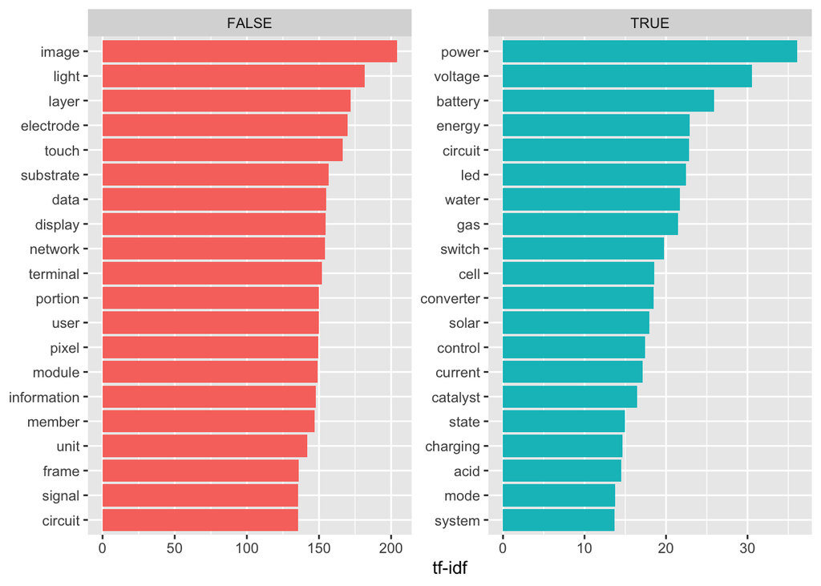

```r
pat_ytag_words %>%
  ggplot(aes(x = word, y = tf_idf, fill = y_tag)) +
  geom_col(show.legend = FALSE) +
  labs(x = NULL, y = "tf-idf") +
  facet_wrap(~y_tag, ncol = 2, scales = "free") +
  coord_flip() +
  scale_x_reordered()
```

# Building a predictive model

```r
data <- pat_abstr %>%
  select(y_tag, appln_abstract) %>%
  rename(y = y_tag, text = appln_abstract) %>%
  mutate(y = y %>% as_factor()) %>%
  mutate(text = text %>% str_to_lower() %>% str_remove_all('[^[:alnum:] ]'))
```

## Training & Test split

```r
data_split <- initial_split(data, prop = 0.75, strata = y)

data_train <- data_split  %>%  training()
data_test <- data_split %>% testing()
```

## Preprocessing pipeline

```r
library(textrecipes)
```

```r
data_recipe <- data_train %>%
  recipe(y ~.) %>%
  step_downsample(y) %>%
  step_filter(text != "") %>%
  step_tokenize(text) %>%
  step_tokenfilter(text, min_times = 100) %>%
  step_stopwords(text, keep = FALSE) %>%
  step_tfidf(text) %>%
  prep()
```

```r
data_recipe
```

```
## Data Recipe
##
## Inputs:
##
##       role #variables
##    outcome          1
##  predictor          1
##
## Training data contained 17021 data points and no missing data.
##
## Operations:
##
## Down-sampling based on y [trained]
## Row filtering [trained]
## Tokenization for text [trained]
## Text filtering for text [trained]
## Stop word removal for text [trained]
## Term frequency-inverse document frequency with text [trained]
```

```r
data_train_prep <- data_recipe %>% juice()
data_test_prep <- data_recipe %>% bake(data_test)
```

## Defining the models

```r
all_cores <- parallel::detectCores(logical = FALSE)

library(doParallel)
cl <- makePSOCKcluster(all_cores)
registerDoParallel(cl)
```

```r
model_en <- logistic_reg(mode = 'classification',
                         mixture = 0.0,
                         penalty = 0.25) %>%
  set_engine('glm', family = binomial)
```

## Define the workflow

We will skip the workflow step this time, since we do not evaluate different models against each others.

## fit the model

```r
fit_en <- model_en %>% fit(formula = y ~., data = data_train_prep)
```

```r
pred_collected <- tibble(
  truth = data_train_prep %>% pull(y),
  pred = fit_en %>% predict(new_data = data_train_prep) %>% pull(.pred_class),
  pred_prob = fit_en %>% predict(new_data = data_train_prep, type = "prob") %>% pull(.pred_TRUE),
  )
```

```r
pred_collected %>% conf_mat(truth, pred)
```

```
##           Truth
## Prediction FALSE TRUE
##      FALSE   751  333
##      TRUE    280  698
```

```r
pred_collected %>% conf_mat(truth, pred) %>% summary()
```

| .metric | .estimator | .estimate |
| --- | --- | --- |
| accuracy | binary | 0.7027158 |
| kap | binary | 0.4054316 |
| sens | binary | 0.7284190 |
| spec | binary | 0.6770126 |
| ppv | binary | 0.6928044 |
| npv | binary | 0.7137014 |
| mcc | binary | 0.4059684 |
| j_index | binary | 0.4054316 |
| bal_accuracy | binary | 0.7027158 |
| detection_prevalence | binary | 0.5257032 |

[output cut: 3 more lines]

# Endnotes

### References

- [Hain, D., & Jurowetzki, R. (2020). Introduction to Rare-Event Predictive Modeling for Inferential Statisticians–A Hands-On Application in the Prediction of Breakthrough Patents. arXiv preprint arXiv:2003.13441.](https://arxiv.org/abs/2003.13441)

### Packages and Ecosystem

- [`tidymodels`](https://www.tidymodels.org/): Tidy statistical and predictive modeling ecosystem
- [`tidytext`]

### Further Readings

- [`Tidy Text Mining in R`](https://www.tidytextmining.com/)